# Risk Factor Analysis

## Outcome Variable

**Outcome Variable:** y_rate_haz

## Predictor Variables

**Intervention Variable:** exclfeed36

**Adjustment Set:**

- arm
- sex
- brthmon
- W_mage
- meducyrs
- feducyrs
- hhwealth_quart
- hfoodsec
- W_mhtcm
- W_mwtkg
- W_mbmi
- vagbrth
- W_birthwt
- W_birthlen
- W_nrooms
- month
- W_parity
- impfloor
- impsan
- safeh20
- delta_W_mage
- delta_meducyrs
- delta_feducyrs
- delta_hhwealth_quart
- delta_hfoodsec
- delta_W_mhtcm
- delta_W_mwtkg
- delta_W_mbmi
- delta_vagbrth
- delta_W_birthwt
- delta_W_birthlen
- delta_W_nrooms
- delta_month
- delta_W_parity
- delta_impfloor
- delta_impsan
- delta_safeh20

## Stratifying Variables

The analysis was stratified on these variable(s):

- agecat
- studyid
- country

## Data Summary

| agecat | studyid | country | exclfeed36 | n_cell | n |
| --- | --- | --- | --- | --- | --- |
| 0-3 months | CMC-V-BCS-2002 | INDIA | 1 | 2 | 2 |
| 0-3 months | CMC-V-BCS-2002 | INDIA | 0 | 0 | 2 |
| 0-3 months | EE | PAKISTAN | 1 | 2 | 6 |
| 0-3 months | EE | PAKISTAN | 0 | 4 | 6 |
| 0-3 months | GMS-Nepal | NEPAL | 1 | 372 | 465 |
| 0-3 months | GMS-Nepal | NEPAL | 0 | 93 | 465 |
| 0-3 months | IRC | INDIA | 1 | 0 | 4 |
| 0-3 months | IRC | INDIA | 0 | 4 | 4 |
| 0-3 months | JiVitA-3 | BANGLADESH | 1 | 7572 | 9726 |
| 0-3 months | JiVitA-3 | BANGLADESH | 0 | 2154 | 9726 |
| 0-3 months | JiVitA-4 | BANGLADESH | 1 | 1399 | 1685 |
| 0-3 months | JiVitA-4 | BANGLADESH | 0 | 286 | 1685 |
| 0-3 months | Keneba | GAMBIA | 1 | 326 | 1116 |
| 0-3 months | Keneba | GAMBIA | 0 | 790 | 1116 |
| 0-3 months | MAL-ED | BANGLADESH | 1 | 32 | 242 |
| 0-3 months | MAL-ED | BANGLADESH | 0 | 210 | 242 |
| 0-3 months | MAL-ED | BRAZIL | 1 | 8 | 167 |
| 0-3 months | MAL-ED | BRAZIL | 0 | 159 | 167 |
| 0-3 months | MAL-ED | INDIA | 1 | 4 | 181 |
| 0-3 months | MAL-ED | INDIA | 0 | 177 | 181 |
| 0-3 months | MAL-ED | NEPAL | 1 | 4 | 154 |
| 0-3 months | MAL-ED | NEPAL | 0 | 150 | 154 |
| 0-3 months | MAL-ED | PERU | 1 | 5 | 263 |
| 0-3 months | MAL-ED | PERU | 0 | 258 | 263 |
| 0-3 months | MAL-ED | SOUTH AFRICA | 1 | 0 | 209 |
| 0-3 months | MAL-ED | SOUTH AFRICA | 0 | 209 | 209 |
| 0-3 months | MAL-ED | TANZANIA, UNITED REPUBLIC OF | 1 | 3 | 223 |
| 0-3 months | MAL-ED | TANZANIA, UNITED REPUBLIC OF | 0 | 220 | 223 |
| 0-3 months | PROVIDE | BANGLADESH | 1 | 161 | 634 |
| 0-3 months | PROVIDE | BANGLADESH | 0 | 473 | 634 |

[output cut: 214 more lines]

The following strata were considered:

- agecat: 0-3 months, studyid: CMC-V-BCS-2002, country: INDIA
- agecat: 0-3 months, studyid: EE, country: PAKISTAN
- agecat: 0-3 months, studyid: GMS-Nepal, country: NEPAL
- agecat: 0-3 months, studyid: IRC, country: INDIA
- agecat: 0-3 months, studyid: JiVitA-3, country: BANGLADESH
- agecat: 0-3 months, studyid: JiVitA-4, country: BANGLADESH
- agecat: 0-3 months, studyid: Keneba, country: GAMBIA
- agecat: 0-3 months, studyid: MAL-ED, country: BANGLADESH
- agecat: 0-3 months, studyid: MAL-ED, country: BRAZIL
- agecat: 0-3 months, studyid: MAL-ED, country: INDIA
- agecat: 0-3 months, studyid: MAL-ED, country: NEPAL
- agecat: 0-3 months, studyid: MAL-ED, country: PERU
- agecat: 0-3 months, studyid: MAL-ED, country: SOUTH AFRICA
- agecat: 0-3 months, studyid: MAL-ED, country: TANZANIA, UNITED REPUBLIC OF
- agecat: 0-3 months, studyid: PROVIDE, country: BANGLADESH
- agecat: 12-15 months, studyid: CMC-V-BCS-2002, country: INDIA
- agecat: 12-15 months, studyid: EE, country: PAKISTAN
- agecat: 12-15 months, studyid: GMS-Nepal, country: NEPAL
- agecat: 12-15 months, studyid: IRC, country: INDIA
- agecat: 12-15 months, studyid: JiVitA-4, country: BANGLADESH
- agecat: 12-15 months, studyid: Keneba, country: GAMBIA
- agecat: 12-15 months, studyid: LCNI-5, country: MALAWI
- agecat: 12-15 months, studyid: MAL-ED, country: BANGLADESH
- agecat: 12-15 months, studyid: MAL-ED, country: BRAZIL
- agecat: 12-15 months, studyid: MAL-ED, country: INDIA
- agecat: 12-15 months, studyid: MAL-ED, country: NEPAL
- agecat: 12-15 months, studyid: MAL-ED, country: PERU
- agecat: 12-15 months, studyid: MAL-ED, country: SOUTH AFRICA
- agecat: 12-15 months, studyid: MAL-ED, country: TANZANIA, UNITED REPUBLIC OF
- agecat: 12-15 months, studyid: PROVIDE, country: BANGLADESH
- agecat: 12-15 months, studyid: SAS-FoodSuppl, country: INDIA
- agecat: 15-18 months, studyid: CMC-V-BCS-2002, country: INDIA
- agecat: 15-18 months, studyid: EE, country: PAKISTAN
- agecat: 15-18 months, studyid: GMS-Nepal, country: NEPAL
- agecat: 15-18 months, studyid: IRC, country: INDIA
- agecat: 15-18 months, studyid: JiVitA-4, country: BANGLADESH
- agecat: 15-18 months, studyid: Keneba, country: GAMBIA
- agecat: 15-18 months, studyid: LCNI-5, country: MALAWI
- agecat: 15-18 months, studyid: MAL-ED, country: BANGLADESH
- agecat: 15-18 months, studyid: MAL-ED, country: BRAZIL
- agecat: 15-18 months, studyid: MAL-ED, country: INDIA
- agecat: 15-18 months, studyid: MAL-ED, country: NEPAL
- agecat: 15-18 months, studyid: MAL-ED, country: PERU
- agecat: 15-18 months, studyid: MAL-ED, country: SOUTH AFRICA
- agecat: 15-18 months, studyid: MAL-ED, country: TANZANIA, UNITED REPUBLIC OF
- agecat: 15-18 months, studyid: PROVIDE, country: BANGLADESH
- agecat: 15-18 months, studyid: SAS-FoodSuppl, country: INDIA
- agecat: 18-21 months, studyid: CMC-V-BCS-2002, country: INDIA
- agecat: 18-21 months, studyid: EE, country: PAKISTAN
- agecat: 18-21 months, studyid: GMS-Nepal, country: NEPAL
- agecat: 18-21 months, studyid: IRC, country: INDIA
- agecat: 18-21 months, studyid: Keneba, country: GAMBIA
- agecat: 18-21 months, studyid: LCNI-5, country: MALAWI
- agecat: 18-21 months, studyid: MAL-ED, country: BANGLADESH
- agecat: 18-21 months, studyid: MAL-ED, country: BRAZIL
- agecat: 18-21 months, studyid: MAL-ED, country: INDIA
- agecat: 18-21 months, studyid: MAL-ED, country: NEPAL
- agecat: 18-21 months, studyid: MAL-ED, country: PERU
- agecat: 18-21 months, studyid: MAL-ED, country: SOUTH AFRICA
- agecat: 18-21 months, studyid: MAL-ED, country: TANZANIA, UNITED REPUBLIC OF
- agecat: 18-21 months, studyid: PROVIDE, country: BANGLADESH
- agecat: 21-24 months, studyid: CMC-V-BCS-2002, country: INDIA
- agecat: 21-24 months, studyid: EE, country: PAKISTAN
- agecat: 21-24 months, studyid: GMS-Nepal, country: NEPAL
- agecat: 21-24 months, studyid: IRC, country: INDIA
- agecat: 21-24 months, studyid: Keneba, country: GAMBIA
- agecat: 21-24 months, studyid: LCNI-5, country: MALAWI
- agecat: 21-24 months, studyid: MAL-ED, country: BANGLADESH
- agecat: 21-24 months, studyid: MAL-ED, country: BRAZIL
- agecat: 21-24 months, studyid: MAL-ED, country: INDIA
- agecat: 21-24 months, studyid: MAL-ED, country: NEPAL
- agecat: 21-24 months, studyid: MAL-ED, country: PERU
- agecat: 21-24 months, studyid: MAL-ED, country: SOUTH AFRICA
- agecat: 21-24 months, studyid: MAL-ED, country: TANZANIA, UNITED REPUBLIC OF
- agecat: 21-24 months, studyid: PROVIDE, country: BANGLADESH
- agecat: 3-6 months, studyid: CMC-V-BCS-2002, country: INDIA
- agecat: 3-6 months, studyid: EE, country: PAKISTAN
- agecat: 3-6 months, studyid: GMS-Nepal, country: NEPAL
- agecat: 3-6 months, studyid: IRC, country: INDIA
- agecat: 3-6 months, studyid: JiVitA-3, country: BANGLADESH
- agecat: 3-6 months, studyid: JiVitA-4, country: BANGLADESH
- agecat: 3-6 months, studyid: Keneba, country: GAMBIA
- agecat: 3-6 months, studyid: MAL-ED, country: BANGLADESH
- agecat: 3-6 months, studyid: MAL-ED, country: BRAZIL
- agecat: 3-6 months, studyid: MAL-ED, country: INDIA
- agecat: 3-6 months, studyid: MAL-ED, country: NEPAL
- agecat: 3-6 months, studyid: MAL-ED, country: PERU
- agecat: 3-6 months, studyid: MAL-ED, country: SOUTH AFRICA
- agecat: 3-6 months, studyid: MAL-ED, country: TANZANIA, UNITED REPUBLIC OF
- agecat: 3-6 months, studyid: PROVIDE, country: BANGLADESH
- agecat: 6-9 months, studyid: CMC-V-BCS-2002, country: INDIA
- agecat: 6-9 months, studyid: EE, country: PAKISTAN
- agecat: 6-9 months, studyid: GMS-Nepal, country: NEPAL
- agecat: 6-9 months, studyid: IRC, country: INDIA
- agecat: 6-9 months, studyid: JiVitA-4, country: BANGLADESH
- agecat: 6-9 months, studyid: Keneba, country: GAMBIA
- agecat: 6-9 months, studyid: LCNI-5, country: MALAWI
- agecat: 6-9 months, studyid: MAL-ED, country: BANGLADESH
- agecat: 6-9 months, studyid: MAL-ED, country: BRAZIL
- agecat: 6-9 months, studyid: MAL-ED, country: INDIA
- agecat: 6-9 months, studyid: MAL-ED, country: NEPAL
- agecat: 6-9 months, studyid: MAL-ED, country: PERU
- agecat: 6-9 months, studyid: MAL-ED, country: SOUTH AFRICA
- agecat: 6-9 months, studyid: MAL-ED, country: TANZANIA, UNITED REPUBLIC OF
- agecat: 6-9 months, studyid: PROVIDE, country: BANGLADESH
- agecat: 6-9 months, studyid: SAS-FoodSuppl, country: INDIA
- agecat: 9-12 months, studyid: CMC-V-BCS-2002, country: INDIA
- agecat: 9-12 months, studyid: EE, country: PAKISTAN
- agecat: 9-12 months, studyid: GMS-Nepal, country: NEPAL
- agecat: 9-12 months, studyid: IRC, country: INDIA
- agecat: 9-12 months, studyid: JiVitA-4, country: BANGLADESH
- agecat: 9-12 months, studyid: Keneba, country: GAMBIA
- agecat: 9-12 months, studyid: LCNI-5, country: MALAWI
- agecat: 9-12 months, studyid: MAL-ED, country: BANGLADESH
- agecat: 9-12 months, studyid: MAL-ED, country: BRAZIL
- agecat: 9-12 months, studyid: MAL-ED, country: INDIA
- agecat: 9-12 months, studyid: MAL-ED, country: NEPAL
- agecat: 9-12 months, studyid: MAL-ED, country: PERU
- agecat: 9-12 months, studyid: MAL-ED, country: SOUTH AFRICA
- agecat: 9-12 months, studyid: MAL-ED, country: TANZANIA, UNITED REPUBLIC OF
- agecat: 9-12 months, studyid: PROVIDE, country: BANGLADESH
- agecat: 9-12 months, studyid: SAS-FoodSuppl, country: INDIA

### Dropped Strata

Some strata were dropped due to rare outcomes:

- agecat: 0-3 months, studyid: CMC-V-BCS-2002, country: INDIA
- agecat: 0-3 months, studyid: EE, country: PAKISTAN
- agecat: 0-3 months, studyid: IRC, country: INDIA
- agecat: 0-3 months, studyid: MAL-ED, country: INDIA
- agecat: 0-3 months, studyid: MAL-ED, country: NEPAL
- agecat: 0-3 months, studyid: MAL-ED, country: SOUTH AFRICA
- agecat: 0-3 months, studyid: MAL-ED, country: TANZANIA, UNITED REPUBLIC OF
- agecat: 3-6 months, studyid: CMC-V-BCS-2002, country: INDIA
- agecat: 3-6 months, studyid: EE, country: PAKISTAN
- agecat: 3-6 months, studyid: IRC, country: INDIA
- agecat: 3-6 months, studyid: MAL-ED, country: NEPAL
- agecat: 3-6 months, studyid: MAL-ED, country: SOUTH AFRICA
- agecat: 3-6 months, studyid: MAL-ED, country: TANZANIA, UNITED REPUBLIC OF
- agecat: 6-9 months, studyid: CMC-V-BCS-2002, country: INDIA
- agecat: 6-9 months, studyid: EE, country: PAKISTAN
- agecat: 6-9 months, studyid: IRC, country: INDIA
- agecat: 6-9 months, studyid: MAL-ED, country: NEPAL
- agecat: 6-9 months, studyid: MAL-ED, country: SOUTH AFRICA
- agecat: 6-9 months, studyid: MAL-ED, country: TANZANIA, UNITED REPUBLIC OF
- agecat: 6-9 months, studyid: SAS-FoodSuppl, country: INDIA
- agecat: 9-12 months, studyid: CMC-V-BCS-2002, country: INDIA
- agecat: 9-12 months, studyid: EE, country: PAKISTAN
- agecat: 9-12 months, studyid: IRC, country: INDIA
- agecat: 9-12 months, studyid: MAL-ED, country: NEPAL
- agecat: 9-12 months, studyid: MAL-ED, country: SOUTH AFRICA
- agecat: 9-12 months, studyid: MAL-ED, country: TANZANIA, UNITED REPUBLIC OF
- agecat: 9-12 months, studyid: SAS-FoodSuppl, country: INDIA
- agecat: 12-15 months, studyid: CMC-V-BCS-2002, country: INDIA
- agecat: 12-15 months, studyid: EE, country: PAKISTAN
- agecat: 12-15 months, studyid: IRC, country: INDIA
- agecat: 12-15 months, studyid: LCNI-5, country: MALAWI
- agecat: 12-15 months, studyid: MAL-ED, country: NEPAL
- agecat: 12-15 months, studyid: MAL-ED, country: SOUTH AFRICA
- agecat: 12-15 months, studyid: MAL-ED, country: TANZANIA, UNITED REPUBLIC OF
- agecat: 12-15 months, studyid: SAS-FoodSuppl, country: INDIA
- agecat: 15-18 months, studyid: CMC-V-BCS-2002, country: INDIA
- agecat: 15-18 months, studyid: EE, country: PAKISTAN
- agecat: 15-18 months, studyid: IRC, country: INDIA
- agecat: 15-18 months, studyid: LCNI-5, country: MALAWI
- agecat: 15-18 months, studyid: MAL-ED, country: NEPAL
- agecat: 15-18 months, studyid: MAL-ED, country: SOUTH AFRICA
- agecat: 15-18 months, studyid: MAL-ED, country: TANZANIA, UNITED REPUBLIC OF
- agecat: 15-18 months, studyid: SAS-FoodSuppl, country: INDIA
- agecat: 18-21 months, studyid: CMC-V-BCS-2002, country: INDIA
- agecat: 18-21 months, studyid: EE, country: PAKISTAN
- agecat: 18-21 months, studyid: IRC, country: INDIA
- agecat: 18-21 months, studyid: MAL-ED, country: NEPAL
- agecat: 18-21 months, studyid: MAL-ED, country: PERU
- agecat: 18-21 months, studyid: MAL-ED, country: SOUTH AFRICA
- agecat: 18-21 months, studyid: MAL-ED, country: TANZANIA, UNITED REPUBLIC OF
- agecat: 21-24 months, studyid: CMC-V-BCS-2002, country: INDIA
- agecat: 21-24 months, studyid: EE, country: PAKISTAN
- agecat: 21-24 months, studyid: IRC, country: INDIA
- agecat: 21-24 months, studyid: MAL-ED, country: NEPAL
- agecat: 21-24 months, studyid: MAL-ED, country: PERU
- agecat: 21-24 months, studyid: MAL-ED, country: SOUTH AFRICA
- agecat: 21-24 months, studyid: MAL-ED, country: TANZANIA, UNITED REPUBLIC OF

## Methods Detail

We’re interested in the causal parameters $E[Y_a]$ for all values of $a \in \mathcal{A}$. These parameters represent the mean outcome if, possibly contrary to fact, we intervened to set all units to have $A=a$. Under the randomization and positivity assumptions, these are identified by the statistical parameters $\psi_a=E_W[E_{Y|A,W}(Y|A=a,W)]$. In addition, we’re interested in the mean of $Y$, $E[Y]$ under no intervention (the observed mean). We will estimate these parameters by using SuperLearner to fit the relevant likelihood factors – $E_{Y|A,W}(Y|A=a,W)$ and $p(A=a|W)$, and then updating our likelihood fit using a joint TMLE.

For unadjusted analyses ($W=\{\}$), initial likelihoods were estimated using Lrnr_glm to estimate the simple $E(Y|A)$ and Lrnr_mean to estimate $p(A)$. For adjusted analyses, a small library containing Lrnr_glmnet, Lrnr_xgboost, and Lrnr_mean was used.

Having estimated these parameters, we will then use the delta method to estimate relative risks and attributable risks relative to a prespecified baseline level of $A$.

# Results Detail

## Results Plots

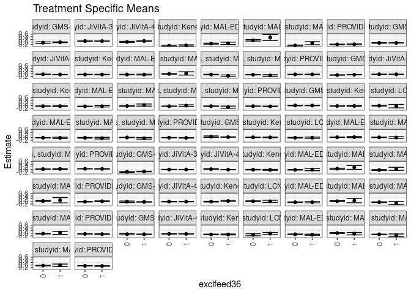

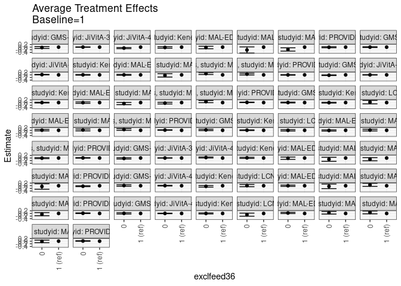

[figure not shown]

## Results Table

### Parameter: TSM

| agecat | studyid | country | intervention_level | baseline_level | estimate | ci_lower | ci_upper |
| --- | --- | --- | --- | --- | --- | --- | --- |
| 0-3 months | GMS-Nepal | NEPAL | 1 | NA | -0.0208882 | -0.0492042 | 0.0074277 |
| 0-3 months | GMS-Nepal | NEPAL | 0 | NA | -0.0515553 | -0.1152777 | 0.0121671 |
| 0-3 months | JiVitA-3 | BANGLADESH | 1 | NA | 0.0687539 | 0.0618853 | 0.0756226 |
| 0-3 months | JiVitA-3 | BANGLADESH | 0 | NA | 0.0719816 | 0.0595822 | 0.0843810 |
| 0-3 months | JiVitA-4 | BANGLADESH | 1 | NA | 0.0759770 | 0.0600635 | 0.0918905 |
| 0-3 months | JiVitA-4 | BANGLADESH | 0 | NA | 0.0067890 | -0.0340558 | 0.0476339 |
| 0-3 months | Keneba | GAMBIA | 1 | NA | -0.2645667 | -0.3113563 | -0.2177771 |
| 0-3 months | Keneba | GAMBIA | 0 | NA | -0.2876413 | -0.3187194 | -0.2565633 |
| 0-3 months | MAL-ED | BANGLADESH | 1 | NA | -0.1010153 | -0.1880628 | -0.0139678 |
| 0-3 months | MAL-ED | BANGLADESH | 0 | NA | -0.1253362 | -0.1625914 | -0.0880811 |
| 0-3 months | MAL-ED | BRAZIL | 1 | NA | 0.3460294 | 0.1166038 | 0.5754549 |
| 0-3 months | MAL-ED | BRAZIL | 0 | NA | 0.1287992 | 0.0709434 | 0.1866551 |
| 0-3 months | MAL-ED | PERU | 1 | NA | -0.0942168 | -0.2126675 | 0.0242339 |
| 0-3 months | MAL-ED | PERU | 0 | NA | -0.2685187 | -0.3031690 | -0.2338684 |
| 0-3 months | PROVIDE | BANGLADESH | 1 | NA | -0.1792009 | -0.2105920 | -0.1478098 |
| 0-3 months | PROVIDE | BANGLADESH | 0 | NA | -0.1876509 | -0.2083004 | -0.1670014 |
| 3-6 months | GMS-Nepal | NEPAL | 1 | NA | -0.1585484 | -0.1790635 | -0.1380334 |
| 3-6 months | GMS-Nepal | NEPAL | 0 | NA | -0.1878621 | -0.2337423 | -0.1419819 |
| 3-6 months | JiVitA-3 | BANGLADESH | 1 | NA | -0.0062784 | -0.0136917 | 0.0011349 |
| 3-6 months | JiVitA-3 | BANGLADESH | 0 | NA | -0.0061181 | -0.0187305 | 0.0064942 |
| 3-6 months | JiVitA-4 | BANGLADESH | 1 | NA | -0.0165115 | -0.0317845 | -0.0012385 |
| 3-6 months | JiVitA-4 | BANGLADESH | 0 | NA | 0.0206257 | -0.0141974 | 0.0554488 |
| 3-6 months | Keneba | GAMBIA | 1 | NA | -0.0310830 | -0.0671341 | 0.0049681 |
| 3-6 months | Keneba | GAMBIA | 0 | NA | -0.0160418 | -0.0394013 | 0.0073177 |
| 3-6 months | MAL-ED | BANGLADESH | 1 | NA | -0.0111176 | -0.0972581 | 0.0750229 |
| 3-6 months | MAL-ED | BANGLADESH | 0 | NA | -0.0261470 | -0.0504637 | -0.0018303 |
| 3-6 months | MAL-ED | BRAZIL | 1 | NA | 0.1534702 | 0.0054346 | 0.3015057 |
| 3-6 months | MAL-ED | BRAZIL | 0 | NA | 0.0579233 | 0.0202079 | 0.0956388 |
| 3-6 months | MAL-ED | INDIA | 1 | NA | 0.0473608 | -0.0695552 | 0.1642768 |
| 3-6 months | MAL-ED | INDIA | 0 | NA | -0.0431444 | -0.0731638 | -0.0131251 |

[output cut: 100 more lines]

### Parameter: E(Y)

| agecat | studyid | country | intervention_level | baseline_level | estimate | ci_lower | ci_upper |
| --- | --- | --- | --- | --- | --- | --- | --- |
| 0-3 months | GMS-Nepal | NEPAL | NA | NA | -0.0244364 | -0.0506014 | 0.0017286 |
| 0-3 months | JiVitA-3 | BANGLADESH | NA | NA | 0.0694017 | 0.0630146 | 0.0757888 |
| 0-3 months | JiVitA-4 | BANGLADESH | NA | NA | 0.0642202 | 0.0489852 | 0.0794552 |
| 0-3 months | Keneba | GAMBIA | NA | NA | -0.2813600 | -0.3072816 | -0.2554385 |
| 0-3 months | MAL-ED | BANGLADESH | NA | NA | -0.1219910 | -0.1558661 | -0.0881159 |
| 0-3 months | MAL-ED | BRAZIL | NA | NA | 0.1392055 | 0.0825938 | 0.1958172 |
| 0-3 months | MAL-ED | PERU | NA | NA | -0.2652050 | -0.2992408 | -0.2311692 |
| 0-3 months | PROVIDE | BANGLADESH | NA | NA | -0.1881464 | -0.2054815 | -0.1708113 |
| 3-6 months | GMS-Nepal | NEPAL | NA | NA | -0.1619144 | -0.1807661 | -0.1430628 |
| 3-6 months | JiVitA-3 | BANGLADESH | NA | NA | -0.0062187 | -0.0128267 | 0.0003893 |
| 3-6 months | JiVitA-4 | BANGLADESH | NA | NA | -0.0104148 | -0.0243612 | 0.0035317 |
| 3-6 months | Keneba | GAMBIA | NA | NA | -0.0181994 | -0.0377516 | 0.0013528 |
| 3-6 months | MAL-ED | BANGLADESH | NA | NA | -0.0232296 | -0.0468728 | 0.0004136 |
| 3-6 months | MAL-ED | BRAZIL | NA | NA | 0.0597292 | 0.0232017 | 0.0962566 |
| 3-6 months | MAL-ED | INDIA | NA | NA | -0.0395718 | -0.0688631 | -0.0102806 |
| 3-6 months | MAL-ED | PERU | NA | NA | 0.0257461 | -0.0055184 | 0.0570106 |
| 3-6 months | PROVIDE | BANGLADESH | NA | NA | -0.0259615 | -0.0417668 | -0.0101562 |
| 6-9 months | GMS-Nepal | NEPAL | NA | NA | -0.0452273 | -0.0630261 | -0.0274285 |
| 6-9 months | JiVitA-4 | BANGLADESH | NA | NA | -0.0285349 | -0.0378750 | -0.0191949 |
| 6-9 months | Keneba | GAMBIA | NA | NA | -0.0112500 | -0.0357999 | 0.0132998 |
| 6-9 months | LCNI-5 | MALAWI | NA | NA | 0.0095862 | -0.0174314 | 0.0366037 |
| 6-9 months | MAL-ED | BANGLADESH | NA | NA | -0.0700232 | -0.0872813 | -0.0527650 |
| 6-9 months | MAL-ED | BRAZIL | NA | NA | 0.0087834 | -0.0260798 | 0.0436466 |
| 6-9 months | MAL-ED | INDIA | NA | NA | -0.0730606 | -0.0957376 | -0.0503836 |
| 6-9 months | MAL-ED | PERU | NA | NA | -0.0335784 | -0.0576919 | -0.0094649 |
| 6-9 months | PROVIDE | BANGLADESH | NA | NA | -0.0614264 | -0.0722690 | -0.0505838 |
| 9-12 months | GMS-Nepal | NEPAL | NA | NA | -0.0800260 | -0.0943928 | -0.0656593 |
| 9-12 months | JiVitA-4 | BANGLADESH | NA | NA | -0.0531058 | -0.0612606 | -0.0449509 |
| 9-12 months | Keneba | GAMBIA | NA | NA | -0.0987979 | -0.1174339 | -0.0801618 |
| 9-12 months | LCNI-5 | MALAWI | NA | NA | -0.1052774 | -0.1637460 | -0.0468087 |
| 9-12 months | MAL-ED | BANGLADESH | NA | NA | -0.0872054 | -0.1033675 | -0.0710433 |
| 9-12 months | MAL-ED | BRAZIL | NA | NA | 0.0081784 | -0.0226414 | 0.0389982 |
| 9-12 months | MAL-ED | INDIA | NA | NA | -0.0918936 | -0.1079066 | -0.0758806 |
| 9-12 months | MAL-ED | PERU | NA | NA | -0.0419261 | -0.0633861 | -0.0204661 |
| 9-12 months | PROVIDE | BANGLADESH | NA | NA | -0.0628687 | -0.0738539 | -0.0518835 |
| 12-15 months | GMS-Nepal | NEPAL | NA | NA | -0.0707654 | -0.0805279 | -0.0610030 |
| 12-15 months | JiVitA-4 | BANGLADESH | NA | NA | -0.0465550 | -0.0533118 | -0.0397982 |
| 12-15 months | Keneba | GAMBIA | NA | NA | -0.0513458 | -0.0638293 | -0.0388624 |
| 12-15 months | MAL-ED | BANGLADESH | NA | NA | -0.0557123 | -0.0712495 | -0.0401751 |
| 12-15 months | MAL-ED | BRAZIL | NA | NA | -0.0030430 | -0.0256176 | 0.0195316 |
| 12-15 months | MAL-ED | INDIA | NA | NA | -0.0576039 | -0.0729359 | -0.0422719 |
| 12-15 months | MAL-ED | PERU | NA | NA | -0.0653532 | -0.0832313 | -0.0474751 |
| 12-15 months | PROVIDE | BANGLADESH | NA | NA | -0.0408493 | -0.0509622 | -0.0307364 |
| 15-18 months | GMS-Nepal | NEPAL | NA | NA | -0.0676012 | -0.0796397 | -0.0555626 |
| 15-18 months | JiVitA-4 | BANGLADESH | NA | NA | -0.0333707 | -0.0399958 | -0.0267456 |
| 15-18 months | Keneba | GAMBIA | NA | NA | -0.0329424 | -0.0454411 | -0.0204438 |
| 15-18 months | MAL-ED | BANGLADESH | NA | NA | -0.0457943 | -0.0592710 | -0.0323176 |
| 15-18 months | MAL-ED | BRAZIL | NA | NA | -0.0203422 | -0.0414264 | 0.0007419 |
| 15-18 months | MAL-ED | INDIA | NA | NA | -0.0367528 | -0.0495674 | -0.0239382 |
| 15-18 months | MAL-ED | PERU | NA | NA | -0.0360565 | -0.0515481 | -0.0205649 |
| 15-18 months | PROVIDE | BANGLADESH | NA | NA | -0.0375600 | -0.0463196 | -0.0288004 |
| 18-21 months | GMS-Nepal | NEPAL | NA | NA | 0.0158061 | 0.0032947 | 0.0283174 |
| 18-21 months | Keneba | GAMBIA | NA | NA | -0.0215104 | -0.0346731 | -0.0083477 |
| 18-21 months | LCNI-5 | MALAWI | NA | NA | -0.0092283 | -0.0423286 | 0.0238719 |
| 18-21 months | MAL-ED | BANGLADESH | NA | NA | -0.0155219 | -0.0271478 | -0.0038959 |
| 18-21 months | MAL-ED | BRAZIL | NA | NA | -0.0203590 | -0.0449122 | 0.0041942 |
| 18-21 months | MAL-ED | INDIA | NA | NA | 0.0047911 | -0.0066468 | 0.0162289 |
| 18-21 months | PROVIDE | BANGLADESH | NA | NA | -0.0109038 | -0.0190771 | -0.0027305 |
| 21-24 months | GMS-Nepal | NEPAL | NA | NA | 0.0449374 | 0.0286985 | 0.0611763 |
| 21-24 months | Keneba | GAMBIA | NA | NA | 0.0185345 | 0.0063004 | 0.0307686 |
| 21-24 months | LCNI-5 | MALAWI | NA | NA | -0.0116248 | -0.0336145 | 0.0103649 |
| 21-24 months | MAL-ED | BANGLADESH | NA | NA | 0.0256182 | 0.0134577 | 0.0377787 |
| 21-24 months | MAL-ED | BRAZIL | NA | NA | 0.0164870 | 0.0004862 | 0.0324878 |
| 21-24 months | MAL-ED | INDIA | NA | NA | 0.0301809 | 0.0192922 | 0.0410697 |
| 21-24 months | PROVIDE | BANGLADESH | NA | NA | 0.0463714 | 0.0377102 | 0.0550326 |

### Parameter: ATE

| agecat | studyid | country | intervention_level | baseline_level | estimate | ci_lower | ci_upper |
| --- | --- | --- | --- | --- | --- | --- | --- |
| 0-3 months | GMS-Nepal | NEPAL | 1 | 1 | 0.0000000 | 0.0000000 | 0.0000000 |
| 0-3 months | GMS-Nepal | NEPAL | 0 | 1 | -0.0306671 | -0.0999788 | 0.0386447 |
| 0-3 months | JiVitA-3 | BANGLADESH | 1 | 1 | 0.0000000 | 0.0000000 | 0.0000000 |
| 0-3 months | JiVitA-3 | BANGLADESH | 0 | 1 | 0.0032277 | -0.0099534 | 0.0164087 |
| 0-3 months | JiVitA-4 | BANGLADESH | 1 | 1 | 0.0000000 | 0.0000000 | 0.0000000 |
| 0-3 months | JiVitA-4 | BANGLADESH | 0 | 1 | -0.0691880 | -0.1125327 | -0.0258432 |
| 0-3 months | Keneba | GAMBIA | 1 | 1 | 0.0000000 | 0.0000000 | 0.0000000 |
| 0-3 months | Keneba | GAMBIA | 0 | 1 | -0.0230747 | -0.0792681 | 0.0331188 |
| 0-3 months | MAL-ED | BANGLADESH | 1 | 1 | 0.0000000 | 0.0000000 | 0.0000000 |
| 0-3 months | MAL-ED | BANGLADESH | 0 | 1 | -0.0243209 | -0.1199351 | 0.0712932 |
| 0-3 months | MAL-ED | BRAZIL | 1 | 1 | 0.0000000 | 0.0000000 | 0.0000000 |
| 0-3 months | MAL-ED | BRAZIL | 0 | 1 | -0.2172301 | -0.4538382 | 0.0193780 |
| 0-3 months | MAL-ED | PERU | 1 | 1 | 0.0000000 | 0.0000000 | 0.0000000 |
| 0-3 months | MAL-ED | PERU | 0 | 1 | -0.1743019 | -0.2977168 | -0.0508871 |
| 0-3 months | PROVIDE | BANGLADESH | 1 | 1 | 0.0000000 | 0.0000000 | 0.0000000 |
| 0-3 months | PROVIDE | BANGLADESH | 0 | 1 | -0.0084501 | -0.0461102 | 0.0292100 |
| 3-6 months | GMS-Nepal | NEPAL | 1 | 1 | 0.0000000 | 0.0000000 | 0.0000000 |
| 3-6 months | GMS-Nepal | NEPAL | 0 | 1 | -0.0293137 | -0.0796513 | 0.0210240 |
| 3-6 months | JiVitA-3 | BANGLADESH | 1 | 1 | 0.0000000 | 0.0000000 | 0.0000000 |
| 3-6 months | JiVitA-3 | BANGLADESH | 0 | 1 | 0.0001603 | -0.0139315 | 0.0142520 |
| 3-6 months | JiVitA-4 | BANGLADESH | 1 | 1 | 0.0000000 | 0.0000000 | 0.0000000 |
| 3-6 months | JiVitA-4 | BANGLADESH | 0 | 1 | 0.0371372 | -0.0008265 | 0.0751010 |
| 3-6 months | Keneba | GAMBIA | 1 | 1 | 0.0000000 | 0.0000000 | 0.0000000 |
| 3-6 months | Keneba | GAMBIA | 0 | 1 | 0.0150412 | -0.0278786 | 0.0579610 |
| 3-6 months | MAL-ED | BANGLADESH | 1 | 1 | 0.0000000 | 0.0000000 | 0.0000000 |
| 3-6 months | MAL-ED | BANGLADESH | 0 | 1 | -0.0150294 | -0.1045671 | 0.0745083 |
| 3-6 months | MAL-ED | BRAZIL | 1 | 1 | 0.0000000 | 0.0000000 | 0.0000000 |
| 3-6 months | MAL-ED | BRAZIL | 0 | 1 | -0.0955468 | -0.2481419 | 0.0570483 |
| 3-6 months | MAL-ED | INDIA | 1 | 1 | 0.0000000 | 0.0000000 | 0.0000000 |
| 3-6 months | MAL-ED | INDIA | 0 | 1 | -0.0905052 | -0.2112135 | 0.0302032 |

[output cut: 100 more lines]

### Parameter: PAR

| agecat | studyid | country | intervention_level | baseline_level | estimate | ci_lower | ci_upper |
| --- | --- | --- | --- | --- | --- | --- | --- |
| 0-3 months | GMS-Nepal | NEPAL | 1 | NA | -0.0035482 | -0.0173665 | 0.0102701 |
| 0-3 months | JiVitA-3 | BANGLADESH | 1 | NA | 0.0006478 | -0.0022680 | 0.0035635 |
| 0-3 months | JiVitA-4 | BANGLADESH | 1 | NA | -0.0117568 | -0.0192070 | -0.0043067 |
| 0-3 months | Keneba | GAMBIA | 1 | NA | -0.0167934 | -0.0567401 | 0.0231533 |
| 0-3 months | MAL-ED | BANGLADESH | 1 | NA | -0.0209757 | -0.1049372 | 0.0629858 |
| 0-3 months | MAL-ED | BRAZIL | 1 | NA | -0.2068239 | -0.4322080 | 0.0185602 |
| 0-3 months | MAL-ED | PERU | 1 | NA | -0.1709882 | -0.2913522 | -0.0506243 |
| 0-3 months | PROVIDE | BANGLADESH | 1 | NA | -0.0089456 | -0.0371348 | 0.0192437 |
| 3-6 months | GMS-Nepal | NEPAL | 1 | NA | -0.0033660 | -0.0137574 | 0.0070254 |
| 3-6 months | JiVitA-3 | BANGLADESH | 1 | NA | 0.0000597 | -0.0031947 | 0.0033141 |
| 3-6 months | JiVitA-4 | BANGLADESH | 1 | NA | 0.0060968 | 0.0001209 | 0.0120726 |
| 3-6 months | Keneba | GAMBIA | 1 | NA | 0.0128836 | -0.0189229 | 0.0446901 |
| 3-6 months | MAL-ED | BANGLADESH | 1 | NA | -0.0121120 | -0.0913645 | 0.0671405 |
| 3-6 months | MAL-ED | BRAZIL | 1 | NA | -0.0937410 | -0.2377949 | 0.0503129 |
| 3-6 months | MAL-ED | INDIA | 1 | NA | -0.0869326 | -0.2028988 | 0.0290336 |
| 3-6 months | MAL-ED | PERU | 1 | NA | -0.0564777 | -0.2582903 | 0.1453349 |
| 3-6 months | PROVIDE | BANGLADESH | 1 | NA | -0.0285764 | -0.0554552 | -0.0016975 |
| 6-9 months | GMS-Nepal | NEPAL | 1 | NA | 0.0026361 | -0.0086740 | 0.0139462 |
| 6-9 months | JiVitA-4 | BANGLADESH | 1 | NA | 0.0009912 | -0.0037880 | 0.0057704 |
| 6-9 months | Keneba | GAMBIA | 1 | NA | -0.0326215 | -0.0759050 | 0.0106620 |
| 6-9 months | LCNI-5 | MALAWI | 1 | NA | 0.0107920 | -0.0621052 | 0.0836893 |
| 6-9 months | MAL-ED | BANGLADESH | 1 | NA | 0.0004408 | -0.0451433 | 0.0460248 |
| 6-9 months | MAL-ED | BRAZIL | 1 | NA | -0.0465665 | -0.2117413 | 0.1186082 |
| 6-9 months | MAL-ED | INDIA | 1 | NA | 0.0631722 | -0.0455117 | 0.1718560 |
| 6-9 months | MAL-ED | PERU | 1 | NA | -0.0550670 | -0.1720744 | 0.0619404 |
| 6-9 months | PROVIDE | BANGLADESH | 1 | NA | 0.0111867 | -0.0080919 | 0.0304653 |
| 9-12 months | GMS-Nepal | NEPAL | 1 | NA | 0.0010290 | -0.0078467 | 0.0099047 |
| 9-12 months | JiVitA-4 | BANGLADESH | 1 | NA | 0.0007305 | -0.0034532 | 0.0049142 |
| 9-12 months | Keneba | GAMBIA | 1 | NA | -0.0005375 | -0.0284394 | 0.0273643 |
| 9-12 months | LCNI-5 | MALAWI | 1 | NA | -0.0732565 | -0.1567847 | 0.0102716 |
| 9-12 months | MAL-ED | BANGLADESH | 1 | NA | 0.0306106 | -0.0101553 | 0.0713765 |
| 9-12 months | MAL-ED | BRAZIL | 1 | NA | 0.0488788 | -0.0428891 | 0.1406467 |
| 9-12 months | MAL-ED | INDIA | 1 | NA | 0.0759162 | -0.0276241 | 0.1794566 |
| 9-12 months | MAL-ED | PERU | 1 | NA | -0.0200452 | -0.1159776 | 0.0758873 |
| 9-12 months | PROVIDE | BANGLADESH | 1 | NA | 0.0102754 | -0.0092750 | 0.0298257 |
| 12-15 months | GMS-Nepal | NEPAL | 1 | NA | -0.0000772 | -0.0052951 | 0.0051406 |
| 12-15 months | JiVitA-4 | BANGLADESH | 1 | NA | 0.0036931 | -0.0002535 | 0.0076397 |
| 12-15 months | Keneba | GAMBIA | 1 | NA | 0.0019691 | -0.0152537 | 0.0191919 |
| 12-15 months | MAL-ED | BANGLADESH | 1 | NA | 0.0006350 | -0.0325986 | 0.0338686 |
| 12-15 months | MAL-ED | BRAZIL | 1 | NA | -0.0358185 | -0.1589451 | 0.0873080 |
| 12-15 months | MAL-ED | INDIA | 1 | NA | 0.0930161 | 0.0231251 | 0.1629071 |
| 12-15 months | MAL-ED | PERU | 1 | NA | 0.0571791 | -0.0042960 | 0.1186542 |
| 12-15 months | PROVIDE | BANGLADESH | 1 | NA | -0.0020974 | -0.0183385 | 0.0141438 |
| 15-18 months | GMS-Nepal | NEPAL | 1 | NA | -0.0052534 | -0.0101057 | -0.0004011 |
| 15-18 months | JiVitA-4 | BANGLADESH | 1 | NA | 0.0004979 | -0.0028792 | 0.0038751 |
| 15-18 months | Keneba | GAMBIA | 1 | NA | -0.0013108 | -0.0207731 | 0.0181515 |
| 15-18 months | MAL-ED | BANGLADESH | 1 | NA | -0.0036306 | -0.0549047 | 0.0476434 |
| 15-18 months | MAL-ED | BRAZIL | 1 | NA | -0.0694653 | -0.1479902 | 0.0090595 |
| 15-18 months | MAL-ED | INDIA | 1 | NA | -0.0392410 | -0.1016113 | 0.0231293 |
| 15-18 months | MAL-ED | PERU | 1 | NA | 0.0714906 | -0.0096928 | 0.1526739 |
| 15-18 months | PROVIDE | BANGLADESH | 1 | NA | 0.0102317 | -0.0051448 | 0.0256083 |
| 18-21 months | GMS-Nepal | NEPAL | 1 | NA | 0.0014492 | -0.0043113 | 0.0072097 |
| 18-21 months | Keneba | GAMBIA | 1 | NA | -0.0053655 | -0.0274629 | 0.0167318 |
| 18-21 months | LCNI-5 | MALAWI | 1 | NA | 0.0242978 | -0.0843939 | 0.1329894 |
| 18-21 months | MAL-ED | BANGLADESH | 1 | NA | 0.0088775 | -0.0407298 | 0.0584848 |
| 18-21 months | MAL-ED | BRAZIL | 1 | NA | 0.0244174 | -0.0412582 | 0.0900930 |
| 18-21 months | MAL-ED | INDIA | 1 | NA | 0.0579164 | -0.0032339 | 0.1190667 |
| 18-21 months | PROVIDE | BANGLADESH | 1 | NA | 0.0137708 | -0.0008170 | 0.0283586 |
| 21-24 months | GMS-Nepal | NEPAL | 1 | NA | 0.0050280 | -0.0044946 | 0.0145506 |
| 21-24 months | Keneba | GAMBIA | 1 | NA | 0.0044974 | -0.0153718 | 0.0243666 |
| 21-24 months | LCNI-5 | MALAWI | 1 | NA | -0.0021934 | -0.0458139 | 0.0414271 |
| 21-24 months | MAL-ED | BANGLADESH | 1 | NA | -0.0122551 | -0.0557349 | 0.0312246 |
| 21-24 months | MAL-ED | BRAZIL | 1 | NA | 0.0149925 | -0.0451587 | 0.0751437 |
| 21-24 months | MAL-ED | INDIA | 1 | NA | -0.0090053 | -0.0481089 | 0.0300984 |
| 21-24 months | PROVIDE | BANGLADESH | 1 | NA | 0.0039592 | -0.0110753 | 0.0189937 |